# practical_exercise_1, Methods 3, 2021, autumn semester

# 3) Brushing up on the General Linear Model

We’ll do a light start and get you back in the game of thinking about formulae and how to build your linear models  
Finally, we’ll have a few exercises, finishing off today’s practical exercises

## A list of formulae

```r
formula <- y ~ x ## y as a function of x
y ~ 1 ## model the intercept for "y"
y ~ x ## model the main effect of x and the intercept for y
y ~ x + 1 ## the same as above (+ 1 is implicit)
y ~ x + 0 ## model the main effect of x and no intercept
y ~ x - 1 ## the same as above
y ~ 0 ## doesn't model anything (for completeness)
y ~ x + z ## model the main effects x and z (and an intercept)
y ~ x:z ## model interaction of x and z
y ~ x * z ## model the main effects x and z and their interaction
y ~ x + z + x:z ## the same as above
```

## Dataset mtcars

Let’s look at the “mtcars” data:

[, 1] mpg Miles/(US) gallon  
[, 2] cyl Number of cylinders  
[, 3] disp Displacement (cu.in.)  
[, 4] hp Gross horsepower  
[, 5] drat Rear axle ratio  
[, 6] wt Weight (lb/1000)  
[, 7] qsec 1/4 mile time  
[, 8] vs V/S  
[, 9] am Transmission (0 = automatic, 1 = manual)  
[,10] gear Number of forward gears  
[,11] carb Number of carburetors

## Miles per gallon and weight

We can do a scatter plot, and it looks like there is some relation between fuel usage and the weight of cars. Let’s investigate this further

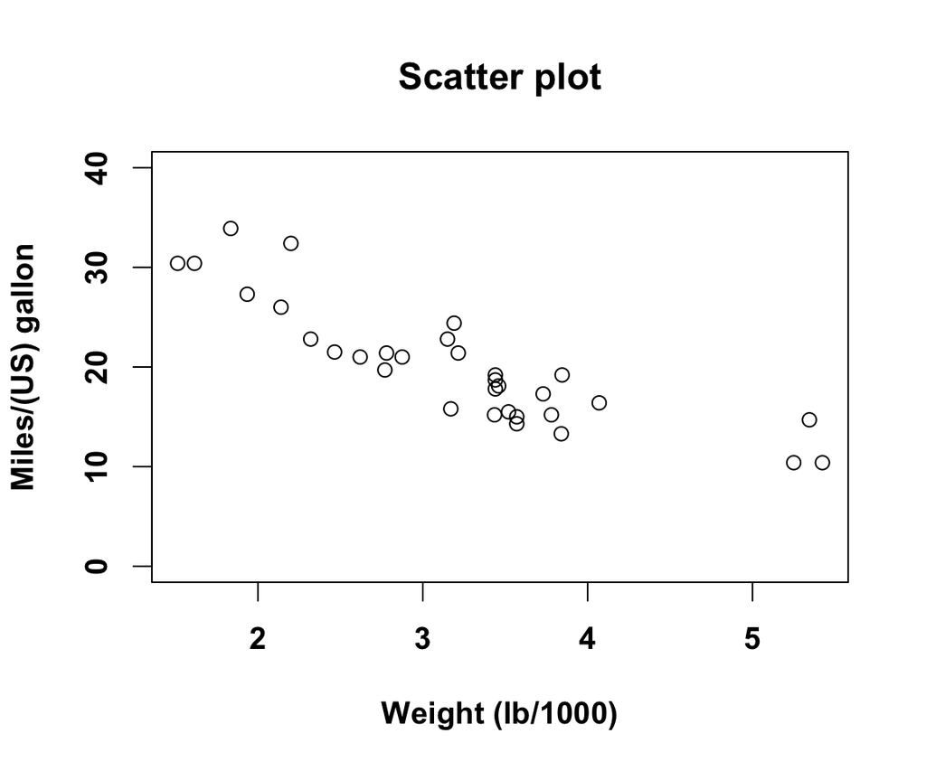

```r
par(font.lab=2, font.axis=2, cex=1.2)
plot(mpg ~ wt, data=mtcars, xlab='Weight (lb/1000)', ylab='Miles/(US) gallon',
     main='Scatter plot', ylim=c(0, 40))
```

# Exercises and objectives

The objectives of today’s exercises are:  
1) To remind you of the (general) linear model, and how we can use it to make models in R  
2) To make some informal model comparisons  
3) To estimate models based on binomially distributed data

If you would like to read more about a given function, just prepend the function with a question mark, e.g.

```r
?lm
```

REMEMBER: In your report, make sure to include code that can reproduce the answers requested in the exercises below

## Exercise 1

The general linear model: $Y = X \beta + \epsilon$:  
Do a linear regression, expressing fuel usage as a function of weight using the function **lm**

```r
data(mtcars)
model <- lm(formula=mpg ~ wt, data=mtcars)
summary(model)
```

```
##
## Call:
## lm(formula = mpg ~ wt, data = mtcars)
##
## Residuals:
##     Min      1Q  Median      3Q     Max
## -4.5432 -2.3647 -0.1252  1.4096  6.8727
##
## Coefficients:
##             Estimate Std. Error t value Pr(>|t|)
## (Intercept)  37.2851     1.8776  19.858  < 2e-16 ***
## wt           -5.3445     0.5591  -9.559 1.29e-10 ***
## ---
## Signif. codes:  0 '***' 0.001 '**' 0.01 '*' 0.05 '.' 0.1 ' ' 1
##
## Residual standard error: 3.046 on 30 degrees of freedom
## Multiple R-squared:  0.7528, Adjusted R-squared:  0.7446
## F-statistic: 91.38 on 1 and 30 DF,  p-value: 1.294e-10
```

1. extract $\hat{\beta}$, $Y$, $\hat{Y}$, $X$ and $\epsilon$ from **model** (hint: have a look at the function **model.matrix**)

```r
betahat <- model$coefficients
y <- mtcars$mpg
yhat <- betahat[1]+betahat[2]*mtcars$wt
x <- mtcars$wt
epsilon <- model$residuals
```

```
i. create a plot that illustrates $Y$ and $\hat{Y}$ (if you are feeling ambitious, also include $\epsilon$ (hint: you can use the function __arrows__))
```

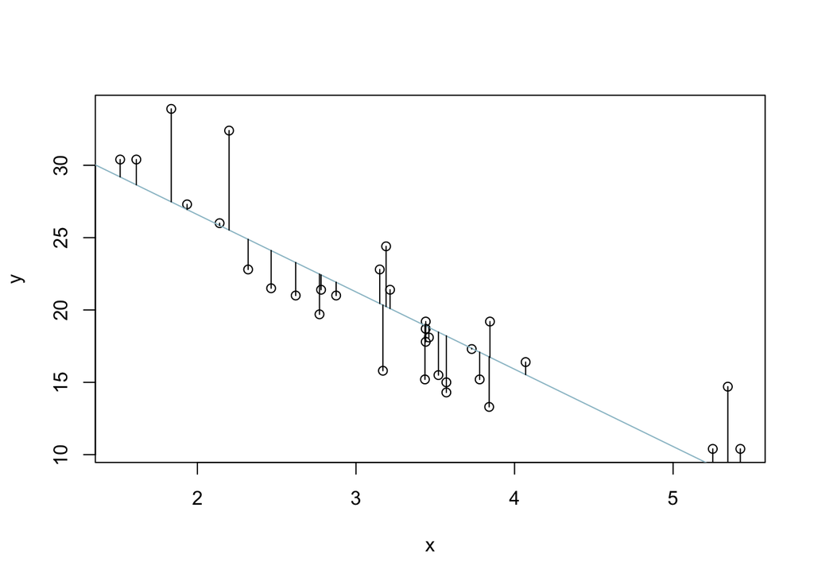

```r
plot(x, y)
abline(a = betahat[1], b = betahat[2], col = "lightblue3")
arrows(x, y, x1= x, y1 = yhat, angle = 0, length = 0)
```

The line illustrates the predicted values $\hat{Y}$ and the dots are the actual values $Y$

2. estimate $\beta$ for a quadratic model ($y = {\beta}_{2} x^2 + {\beta}_{1} x + {\beta}_{0}$) using ordinary least squares *without* using **lm**; $\hat{\beta} = {({X}^{T} X)}^{-1} {X}^{T} Y$ (hint: add a third column to $X$ from step 1)

```r
n <- 32
X <- cbind(rep(1, n), mtcars$wt, (mtcars$wt)^2)

bhats <- solve(t(X)%*%X)%*%t(X)%*%y
bhats
```

```
##            [,1]
## [1,]  49.930811
## [2,] -13.380337
## [3,]   1.171087
```

3. compare your acquired $\hat{\beta}$ with the output of the corresponding quadratic model created using **lm** (hint: use the function **I**, see details under help and the sub-section formula operators here: https://www.datacamp.com/community/tutorials/r-formula-tutorial)

```r
lm2 <- lm(y ~ X[,2] + X[,3])
lm2
```

```
##
## Call:
## lm(formula = y ~ X[, 2] + X[, 3])
##
## Coefficients:
## (Intercept)       X[, 2]       X[, 3]
##      49.931      -13.380        1.171
```

The values are the same!

1. create a plot that illustrates $Y$ and $\hat{Y}$ (if you are feeling ambitious, also include $\epsilon$ (hint: you can use the function **arrows**))

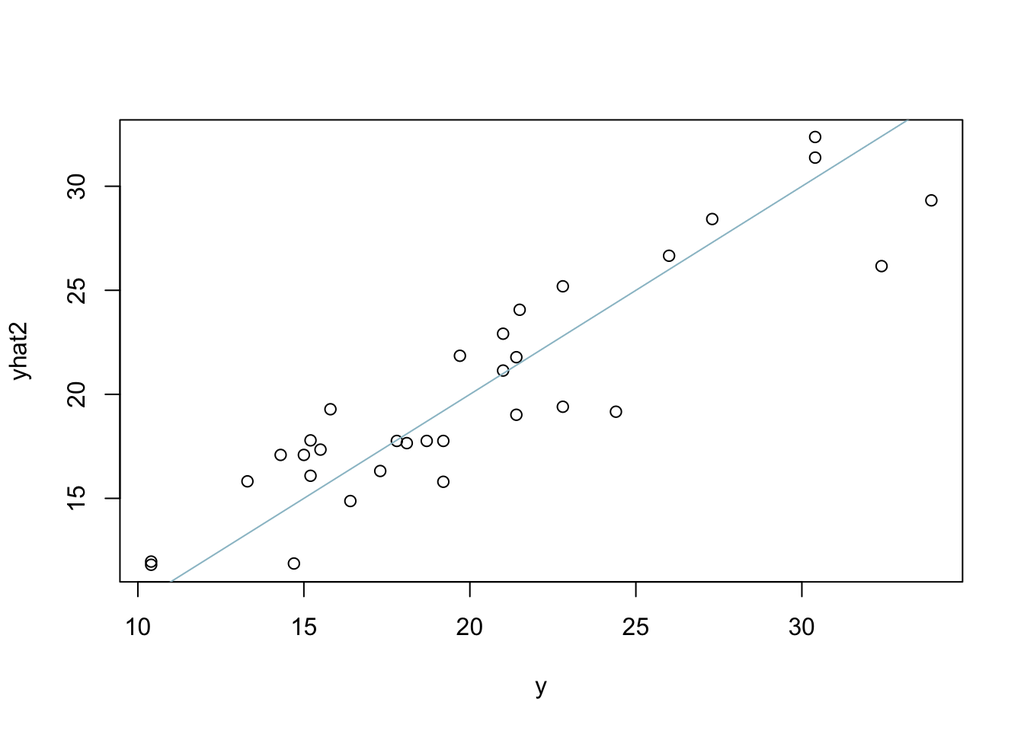

```r
yhat2 <- X%*%bhats
plot(y, yhat2)
abline(a = 0, b = 1, col = "lightblue3")
```

## Exercise 2

Compare the plotted quadratic fit to the linear fit

1. which seems better?

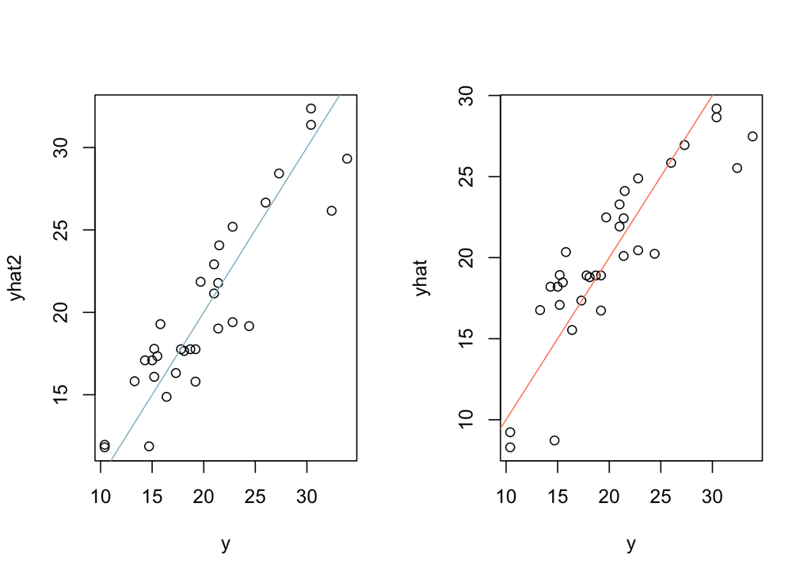

```r
# plotting the same way for the two fits.
par(mfrow=c(1,2))
plot(y, yhat2)
abline(a = 0, b = 1, col = 'lightblue3')
plot(y, yhat)
abline(a = 0, b = 1, col = 'salmon1')
```

The data points seems more equally distributed both above and below close to the line on the plot illustrating the quadratic fit (blue line). It seems as if the quadratic fit may capture the trends of the data better.

2. calculate the sum of squared errors, (show the calculation based on $\epsilon$). Which fit has the lower sum?

```r
# linear
sum((y-yhat)^2)
```

```
## [1] 278.3219
```

```r
# quadratic
sum((y-yhat2)^2)
```

```
## [1] 203.7454
```

3. now make a cubic fit ($y = {\beta}_{3} x^3 + {\beta}_{2} x^2 + {\beta}_{1} x + {\beta}_{0}$) and compare it to the quadratic fit

```r
X3 <- cbind(rep(1, n), mtcars$wt, (mtcars$wt)^2, (mtcars$wt)^3)

bhats3 <- solve(t(X3)%*%X3)%*%t(X3)%*%y
lm3 <-lm(y ~ X3[,2] + X3[,3] + X3[,4])
yhat3 <- X3 %*% bhats3

bhats
```

```
##            [,1]
## [1,]  49.930811
## [2,] -13.380337
## [3,]   1.171087
```

```r
bhats3
```

```
##              [,1]
## [1,]  48.40369623
## [2,] -11.82597602
## [3,]   0.68937919
## [4,]   0.04593618
```

```
i. create a plot that illustrates $Y$ and $\hat{Y}$ for both the cubic and the quadratic fits (plot them in the same plot)
```

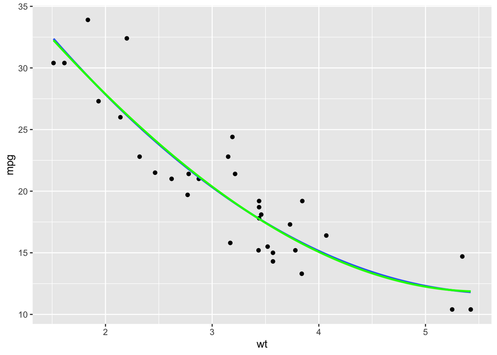

```
ii. compare the sum of squared errors
```

```r
both_plot <- ggplot(mtcars, aes(x = wt, y = mpg))+
  geom_point()+
  #geom_smooth(method = "loess", formula = "y ~ x + x^2", se = FALSE)+
  stat_smooth(method = "lm", formula = y ~ x + I(x^2), size = 1, se = FALSE)+
  stat_smooth(method = "lm", formula = y ~ x + I(x^2) + I(x^3), size = 1, color = "green", se = FALSE)
both_plot
```

```r
# quadratic
sum((y-yhat2)^2)
```

```
## [1] 203.7454
```

```r
# cubic
sum((y-yhat3)^2)
```

```
## [1] 203.6699
```

```
The sum of squared errors for the cubic fit is less than 0.1 smaller than that of the quadratic. Thus, they are almost equal.

iii. what's the estimated value of the "cubic" (${\beta}_3$) parameter? Comment on this!
```

```r
bhats3[4]
```

```
## [1] 0.04593618
```

[output not shown]

4. bonus question: which summary statistic is the fitted value (*Intercept* or ${\beta}_0$ in $y = {\beta}_0$) below identical to?

```
##
## Call:
## lm(formula = mpg ~ 1, data = mtcars)
##
## Coefficients:
## (Intercept)
##       20.09
```

```
## [1] 20.09062
```

Identical to the mean of Miles/(US) gallon.

## Exercise 3

Doing a logistic regression - estimating the probability that a car has automatic transmission (0) or manual transmission (1) based on its weight

```r
data(mtcars)
logistic.model <- glm(formula = am ~ wt, data = mtcars, family = 'binomial')
```

Probabilities live on the range $(0, 1)$ - using the so-called logit function as a “link-function” we can map these onto the range $(-\infty, \infty)$, i.e. the real numbers.

What we model in this case is: $Pr(y = 1) = logit^{-1}(X \beta)$, i.e. the probability of a car having manual transmission, given its weight. $X \beta$ is called the linear predictor; compare with $Y = X \beta + \epsilon$ It is helpful to define the logit function and its inverse function for the following:

```r
logit <-     function(x) log(x / (1 - x))
inv.logit <- function(x) exp(x) / (1 + exp(x))
```

1. plot the fitted values for **logistic.model**:

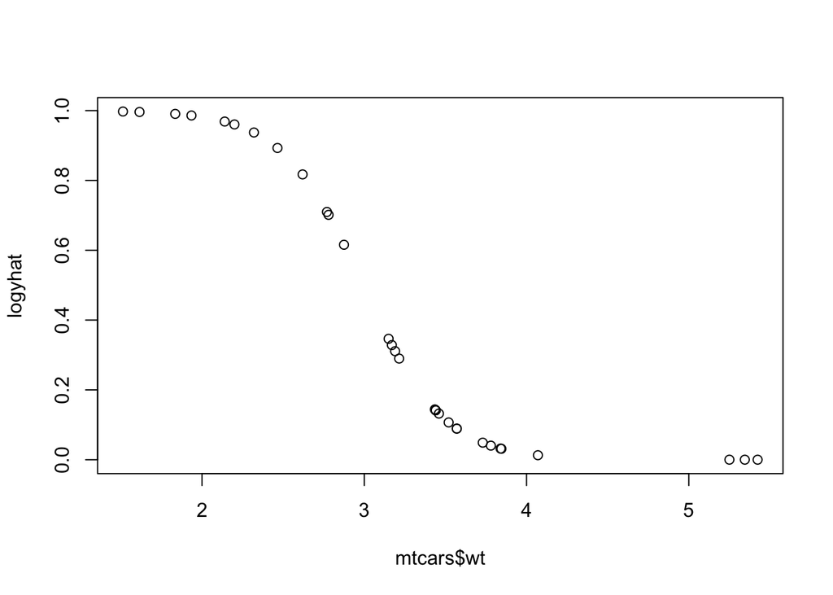

```
i. what is the relation between the __linear.predictors__ and the __fitted_values__ of the __logistic.model__ object?
```

```r
logX <- cbind(rep(1, n), mtcars$wt)
logbetahat <- c(logistic.model$coefficients[1],logistic.model$coefficients[2])

logyhat <- inv.logit(logX%*%logbetahat)
plot(mtcars$wt, logyhat)
```

2. plot the logistic function, you’ve estimated based on your $\hat{\beta}$, (not just the fitted values). Use an *xlim* of (0, 7)

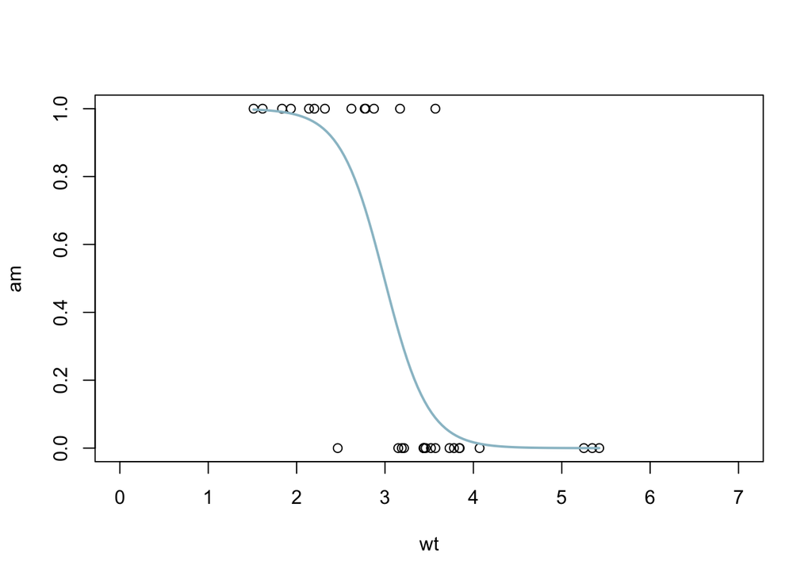

```
i. what's the interpretation of the estimated $\hat{\beta}_0$ (the _Intercept_)
```

```r
newdat <- data.frame(wt=seq(min(mtcars$wt), max(mtcars$wt),len=100))
newdat$am = predict(logistic.model, newdata=newdat, type="response")
plot(am ~ wt, data=mtcars, xlim=c(0,7))
lines(am ~ wt, newdat, col="lightblue3", lwd=2)
```

```r
logyhat[1]
```

```
## [1] 0.8172115
```

```r
inv.logit(logyhat[1])
```

```
## [1] 0.6936441
```

[output not shown]

```r
1-inv.logit(predict(logistic.model, newdata = mtcars[25,]))
```

```
## Pontiac Firebird
##        0.9686836
```

```
The probability that the Pontiac Firebird has automatic transmission is 96.87%

iii. bonus question - plot the logistic function and highlight all the cars where we guessed wrongly, if we used the following "quantizer" function:
```

$$\begin{equation}
transmission_{guess}=
\begin{cases}
1 (manual), & \text{if}\ PR(y = 1) ≥ 0.5 \\
0 (automatic), & \text{otherwise}
\end{cases}
\end{equation}$$

3. plot quadratic fit alongside linear fit

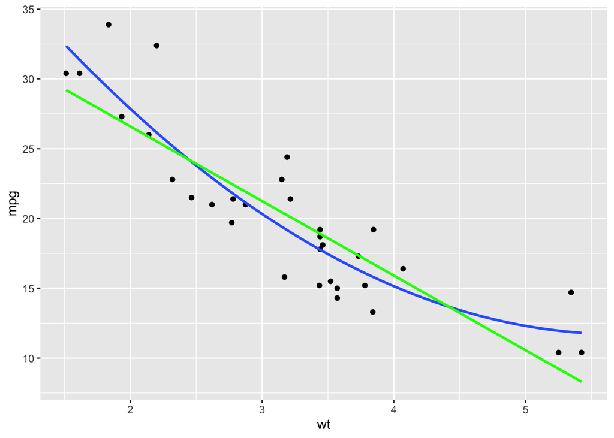

```
i. judging visually, does adding a quadratic term make a difference?
```

```r
both_plot2 <- ggplot(mtcars, aes(x = wt, y = mpg))+
  geom_point()+
  #geom_smooth(method = "loess", formula = "y ~ x + x^2", se = FALSE)+
  stat_smooth(method = "lm", formula = y ~ x + I(x^2), size = 1, se = FALSE)+
  stat_smooth(method = "lm", formula = y ~ x, size = 1, color = "green", se = FALSE)
both_plot2
```

Visually the two lines are not equal. It seems as if the quadratic fir (illustrated by the blue line) captures the trends in the data better than the linear fit. This is especially the case concerning the values of very low weight and of high weight where in both cases the linear fit seems to underestimate the predicted mpg,

```
ii. check the details in the help of the AIC function - which of the models provide the better fit according to the AIC values and the residual deviance respectively?
```

```r
# The linear fit
AIC(model)
```

```
## [1] 166.0294
```

```r
# The quadratic fit
AIC(lm2)
```

```
## [1] 158.0484
```

The model with the lowest AIC is the quadratic fit with AIC=158.05 compared to AIC=166.03 for the linear model. This indicates that the quadratic model provides a better fit.

```
iii. in your own words, why might it be good to penalise a model like the quadratic model, we just fitted.
```

# Next time

We are going to looking at extending our models with so called random effects. We need to install the package “lme4” for this. Run the code below or install it from your package manager (Linux)

```r
install.packages("lme4")
```

We can fit a model like this:

```r
library(lme4)
mixed.model <- lmer(mpg ~ wt + (1 | cyl), data=mtcars)
```

They result in plots like these:

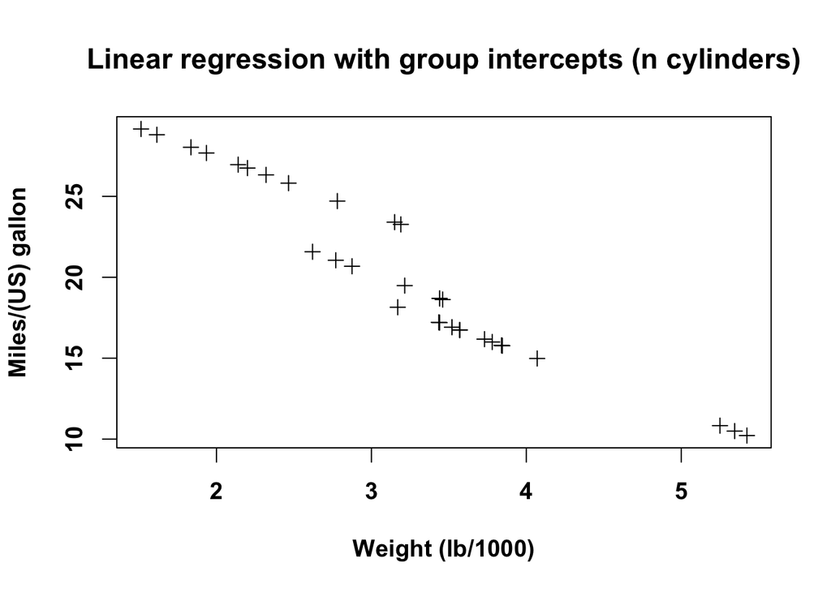

```r
par(font.lab=2, font.axis=2, cex=1.2)
plot(mtcars$wt, fitted.values(mixed.model),
     main='Linear regression with group intercepts (n cylinders)',
    xlab='Weight (lb/1000)', ylab='Miles/(US) gallon',
    pch=3)
```

and this

```r
mixed.model <- lmer(mpg ~ wt + (wt | cyl), data=mtcars)
```

```
## boundary (singular) fit: see ?isSingular
```

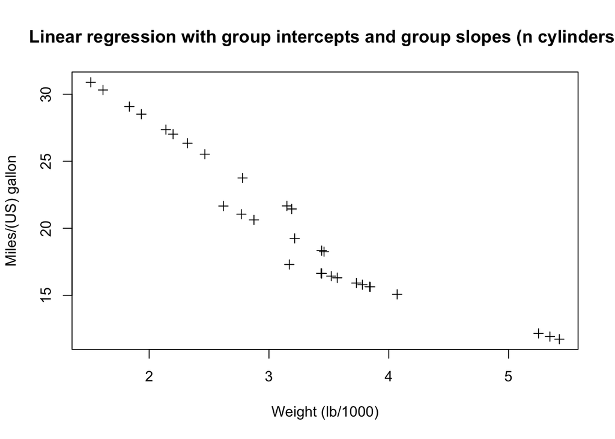

```r
plot(mtcars$wt, fitted.values(mixed.model),
     main='Linear regression with group intercepts and group slopes (n cylinders)',
    xlab='Weight (lb/1000)', ylab='Miles/(US) gallon',
    pch=3)
```

but also new warnings like:

Warning: In checkConv(attr(opt, “derivs”), opt$par, ctrl = control$checkConv, : Model failed to converge with max|grad| = 0.0121962 (tol = 0.002, component 1)